# ADO - PEC2 - Segunda prueba de evaluación contínua - Código

José Félix Rojas Cabeza

2020 - June - 07

# 0.[github](https://github.com/jfrojasc/UOC/tree/master/M0.157%20-%20ADO/PEC2/)

# 1. Abstract

Se utilizó un workflow de `edgeR` para analizar 30 muestras (escogidas aleatoriamanete de un dataset de 292) de tejido tiroideo, con tres niveles de infiltración, proveniente del proyecto [GTEx](https://www.gtexportal.org/home/). Se siguió un [flujo de trabajo](https://bioinformatics-core-shared-training.github.io/cruk-bioinf-sschool/Day3/rnaSeq_DE.pdf) para hacer un perfil de expresión diferencial.

# 2. Objetivos: Que se pretende con este estudio

- Se pretende ubicar los genes diferencialmente expresados, controlando el FDR.
- Las listas se proporcionan como archivos en la carpeta `results`

# 3. Materiales y Métodos:

## 3.1.1 Naturaleza de los datos:

| experiment | SRA_sample | sample_name | analysis_group | body_site | molecular_data_type | sex | group | short_name |
| --- | --- | --- | --- | --- | --- | --- | --- | --- |
| SRX567480 | SRS626942 | GTEX-111CU-0226-SM-5GZXC | 1 | Thyroid | Allele-Specific Expression | male | NIT | 111CU_NIT |
| SRX615964 | SRS644174 | GTEX-111FC-1026-SM-5GZX1 | 1 | Thyroid | RNA Seq (NGS) | male | NIT | 111FC_NIT |
| SRX563960 | SRS625636 | GTEX-111VG-0526-SM-5N9BW | 3 | Thyroid | RNA Seq (NGS) | male | ELI | 111VG_ELI |

## 3.1.2 Tipo de experimento:

Análisis exploratorio de datos y análsis de expresión diferencial de genes.

## 3.1.3 Diseño experimental:

Se comparan tres grupos: Tejidos no infiltrados (control) - NIT, Infiltrados ficales pequeños (Muestra 1) - SFI, Infiltrados linfoides extendidos (Muestra 2) - ELI. Se realizan las siguentes comparaciones:

- NIT vs SFI
- SFI vs ELI
- NIT vs ELI

## 3.2. Métodos y herramientas que habéis utilizado en el análisis:

Workflow típico de `edgeR`, los pasos principales fueron:  
* Creación de objeto de lista DG:

```
dg_list_unf <- DGEList(counts=all_counts,
                       genes=rownames(all_counts),
                       samples=less_targets,
                       group = less_targets$analysis_group)
```

- Normalización: `calcNormFactor(dg_list, method=TMM)`
- Exploración de los datos: `plotMDS(dg_list)`
- Ajuste del Modelo:

```
s_type <- as.character(less_targets$group)
(design_mat_1 <- model.matrix(~ s_type))
(design_mat_2 <- model.matrix(~0+s_type))

dg_list_1 <- estimateGLMCommonDisp(dg_list, design = design_mat)
dg_list_1 <- estimateGLMTrendedDisp(dg_list_1, design = design_mat)
dg_list_1 <- estimateGLMTagwiseDisp(dg_list_1, design = design_mat)

# También se hice para el 2do modelo, uno tiene intersect y el otro no.
```

- Expresión diferencial:

```
fit_1 <- glmFit(dg_list_1, design_mat)
lrt_1 <- glmLRT(fit_1, coef = 3)
# no se utiliza glmQLFit() para no reescalar.
# https://support.bioconductor.org/p/76790/

fit_2 <- glmFit(dg_list_2, design_mat_2)
lrt_2 <- glmLRT(fit_2, coef = 3)

NITvsSFI_df <- as.data.frame(topTags(NITvsSFI))
SFIvsELI_df <- as.data.frame(topTags(SFIvsELI))
NITvsELI_df <- as.data.frame(topTags(NITvsELI))
```

- Anotación

```
library(org.Hs.eg.db)
library(AnnotationDbi)

my_keys <- dg_list$genes$genes

table(my_keys %in% keys(org.Hs.eg.db, keytype = "ENSEMBL"))

annotation_na <- select(org.Hs.eg.db, keys = my_keys,
                        columns = c("ENSEMBL","SYMBOL","GENENAME"),
                        keytype = "ENSEMBL")
```

- Ajuste de p-valor

```
NITvsSFI$table$PValue <- p.adjust(NITvsSFI$table$PValue,"fdr")
SFIvsELI$table$PValue <- p.adjust(SFIvsELI$table$PValue,"fdr")
NITvsELI$table$PValue <- p.adjust(NITvsELI$table$PValue,"fdr")
```

- MA Plot

```
m_NIT <- melt(pseudocounts[,1:10])

x = m_NIT$value
y = m_SFI$value

# M-values
M = x - y

# A-values
A = (x+y)/2

df_ma = data.frame(A, M)

ggplot(df_ma, aes(x = A, y = M)) + geom_point(size = 1.5, alpha = 1/5) +
+ geom_hline(color = "blue3", yintercept = 0) + stat_smooth(se = FALSE, method = "loess", color = "red3")

# un mapa para cada contraste
```

- Heatmap

```
library(RColorBrewer)
mat_dist <- pseudocounts

group <- c(rep("NIT",10),rep("SFI",10),rep("ELI",10))

colnames(mat_dist) = paste(as.character(dg_list_2$samples$short_name), group, sep= " : ")

mat_dist <- as.matrix(dist(t(mat_dist)))

mat_dist <- mat_dist/max(mat_dist)

hmcol <- colorRampPalette(brewer.pal(9, "GnBu"))(16)

cim(mat_dist, color = sort(hmcol, decreasing=T), symkey = FALSE, margins = c(7, 7))
```

## 3.2.1. Procedimiento general de análisis

- Creación de Archivos
- Selección de los datos a utilizar
- Comparación
- Creación de un objeto DGEList
- Filtrado de los datos
- Normalización
- Exploración de datos
- Ajuste del modelo
- Estimación de la dispersión
- Expresión diferencial
  - Listas de Genes diferencialmente expresados
  - Colocar las anotaciones a los resultados de edgeR
  - Anotación enlace

## 3.2.2. Software que habéis utilizado:

Se consultaron los paquetes utilizados con `print(sessionInfo())`: la salida de interés se copia a continuación:

```
other attached packages:
 [1] ensembldb_2.10.2        AnnotationFilter_1.10.0 GenomicFeatures_1.38.2
 [4] GenomicRanges_1.38.0    GenomeInfoDb_1.22.1     RColorBrewer_1.1-2
 [7] reshape_0.8.8           mixOmics_6.10.9         ggplot2_3.3.1
[10] lattice_0.20-38         MASS_7.3-51.5           org.Hs.eg.db_3.10.0
[13] AnnotationDbi_1.48.0    IRanges_2.20.2          S4Vectors_0.24.4
[16] Biobase_2.46.0          BiocGenerics_0.32.0     edgeR_3.28.1
[19] limma_3.42.2            knitr_1.28
```

## 3.3. Descripción del procedimiento:

# 4. Resultados

## Creación de Archivos

```r
> targets <- read.csv("./data/targets.csv", header = TRUE, sep = ",")
> counts <- read.csv2("./data/counts.csv", header = TRUE, sep = ";")
```

```r
> # colocar minúsculas en todos los nombres de variable
> colnames(targets)[1] = "experiment"
> colnames(targets)[2] = "SRA_sample"
> colnames(targets)[3] = "sample_name"
> colnames(targets)[4] = "analysis_group"
> colnames(targets)[8] = "group"
> colnames(targets)[9] = "short_name"
```

```r
> colnames(targets)
```

```
[1] "experiment"          "SRA_sample"          "sample_name"
[4] "analysis_group"      "body_site"           "molecular_data_type"
[7] "sex"                 "group"               "short_name"
```

```r
> ensembl_rownames <- gsub("\\..*", "", counts$X, fixed = FALSE)
> counts$X <- ensembl_rownames
```

## Selección de los datos a utilizar

Escribir un pequeño script que extraiga 10 muestras del grupo 1 (NIT), 10 del grupo 2(SFI), y 10 del grupo 3 (ELI)

```r
> # Groups: 1 - NIT (Not infiltrated tissue) 2 - SFI (Small
> # focal infiltrates) 3 - ELI (Extensive lymphoid infiltrates)
>
> # Reproducibilidad
> set.seed(27021981)
>
> # toma de muestras
> NIT_sample <- targets[sample(which(targets$analysis_group ==
+     1), 10), ]
> SFI_sample <- targets[sample(which(targets$analysis_group ==
+     2), 10), ]
> ELI_sample <- targets[sample(which(targets$analysis_group ==
+     3), 10), ]
>
> NIT_idx <- rownames(NIT_sample)
> SFI_idx <- rownames(SFI_sample)
> ELI_idx <- rownames(ELI_sample)
```

```r
> head(NIT_sample, 3)
```

```
    experiment SRA_sample              sample_name analysis_group body_site
195  SRX203831  SRS374879  GTEX-RVPV-1226-SM-2TF73              1   Thyroid
123  SRX590615  SRS634570 GTEX-13VXT-0626-SM-5SIA1              1   Thyroid
138  SRX634070  SRS648837 GTEX-146FR-0326-SM-5SI8U              1   Thyroid
           molecular_data_type    sex group short_name
195              RNA Seq (NGS)   male   NIT  RVPV-_NIT
123              RNA Seq (NGS) female   NIT  13VXT_NIT
138 Allele-Specific Expression female   NIT  146FR_NIT
```

```r
> head(SFI_sample, 3)
```

```
    experiment SRA_sample              sample_name analysis_group body_site
58   SRX601535  SRS638117 GTEX-12ZZX-1226-SM-5EGHS              2   Thyroid
162  SRX221693  SRS389159  GTEX-OXRP-0326-SM-33HBJ              2   Thyroid
252  SRX630577  SRS648438  GTEX-YFCO-0326-SM-4W1ZP              2   Thyroid
           molecular_data_type    sex group short_name
58               RNA Seq (NGS) female   SFI  12ZZX_SFI
162              RNA Seq (NGS) female   SFI  OXRP-_SFI
252 Allele-Specific Expression   male   SFI  YFCO-_SFI
```

```r
> head(ELI_sample, 3)
```

```
    experiment SRA_sample              sample_name analysis_group body_site
3    SRX563960  SRS625636 GTEX-111VG-0526-SM-5N9BW              3   Thyroid
167  SRX199272  SRS333099  GTEX-PLZ4-1226-SM-2I5FE              3   Thyroid
290  SRX568364  SRS627095  GTEX-ZYY3-1926-SM-5GZXS              3   Thyroid
           molecular_data_type    sex group short_name
3                RNA Seq (NGS)   male   ELI  111VG_ELI
167              RNA Seq (NGS) female   ELI  PLZ4-_ELI
290 Allele-Specific Expression female   ELI  ZYY3-_ELI
```

```r
> # Compatibilización de los nombres de counts
> col_counts <- colnames(counts)
> col_counts <- gsub(".", "-", col_counts, fixed = T)
>
> # https://stackoverflow.com/questions/31518150/gsub-in-r-is-not-replacing-dot
```

```r
> col_id_1 <- vector()
> col_id_2 <- vector()
> col_id_3 <- vector()
>
> for (i in 1:10) {
+     col_id_1[i] <- which(col_counts == as.character(NIT_sample$sample_name[i]))
+     col_id_2[i] <- which(col_counts == as.character(SFI_sample$sample_name[i]))
+     col_id_3[i] <- which(col_counts == as.character(ELI_sample$sample_name[i]))
+ }
>
> col_id_1  #NIT
```

```
 [1] 196 124 139  96   5 143 242 261 255 198
```

```r
> col_id_2  #SFI
```

```
 [1]  59 163 253  47 225  84  10 200  15 103
```

```r
> col_id_3  #ELI
```

```
 [1]   4 168 291 187 252 148 101 150  30 120
```

```r
> as.character(NIT_sample$sample_name[1])
```

```
[1] "GTEX-RVPV-1226-SM-2TF73"
```

```r
> col_counts[col_id_1[1]]
```

```
[1] "GTEX-RVPV-1226-SM-2TF73"
```

```r
> n <- dim(counts)[1]
>
> NIT_counts <- counts[1:n, col_id_1]
> SFI_counts <- counts[1:n, col_id_2]
> ELI_counts <- counts[1:n, col_id_3]
>
> rownames(NIT_counts) <- counts$X
> rownames(SFI_counts) <- counts$X
> rownames(ELI_counts) <- counts$X
```

```r
> dim(counts)
```

```
[1] 56202   293
```

```r
> dim(NIT_counts)
```

```
[1] 56202    10
```

```r
> dim(SFI_counts)
```

```
[1] 56202    10
```

```r
> dim(ELI_counts)
```

```
[1] 56202    10
```

```r
> # Equivalente a: library(SummarizedExperiment) countdata <-
> # assay(all_counts)
>
> all_counts <- cbind(NIT_counts, SFI_counts, ELI_counts)
> write.csv(all_counts, file = "./results/all_counts.csv")
> write.table(all_counts, "./results/all_counts", col.names = T,
+     quote = F, sep = " ", )
> # head(all_counts,3)
```

```r
> dim(all_counts)
```

```
[1] 56202    30
```

```r
> head(rownames(all_counts), 3)
```

```
[1] "ENSG00000223972" "ENSG00000227232" "ENSG00000243485"
```

```r
> head(colnames(all_counts), 3)
```

```
[1] "GTEX.RVPV.1226.SM.2TF73"  "GTEX.13VXT.0626.SM.5SIA1"
[3] "GTEX.146FR.0326.SM.5SI8U"
```

```r
> count_rownames <- rownames(all_counts)
> count_colnames <- colnames(all_counts)
```

Debido a que la literatura recomienda (Love et al. 2015) confirmar que los nombres de las columnas de counts seleccionados correspondan con las filas de targets seleccionadas, se hizo la verificación:

```r
> less_targets <- rbind(NIT_sample, SFI_sample, ELI_sample)
>
> dim(less_targets)
```

```
[1] 30  9
```

## Comparación

```r
> # corrección de nombres para comparación
> subbed_colnames <- cbind(gsub(".", "-", colnames(NIT_counts),
+     fixed = T), gsub(".", "-", colnames(SFI_counts), fixed = T),
+     gsub(".", "-", colnames(ELI_counts), fixed = T))
>
> # comparación
> table(as.character(less_targets$sample_name) == subbed_colnames)
```

```
TRUE
  30
```

## Creación de un objeto DGEList

Se seguirá un workflow propuesto para análisis diferencial de expresión de RNAseq (Rueda and Pereira 2015):

```r
> # Creating a DGEList object
> library(edgeR)
> dg_list_unfiltered <- DGEList(counts = all_counts, genes = rownames(all_counts),
+     samples = less_targets, group = less_targets$analysis_group)
>
> # dim(dg_list) head(dg_list$counts[,1:2]) head(dg_list$genes)
```

## Filtrado de los datos

```r
> # Filtering
> counts_per_million <- cpm(dg_list_unfiltered)
> summary(counts_per_million[, 1:3])
```

```
 GTEX.RVPV.1226.SM.2TF73 GTEX.13VXT.0626.SM.5SIA1 GTEX.146FR.0326.SM.5SI8U
 Min.   :    0.00        Min.   :    0.000        Min.   :    0.00
 1st Qu.:    0.00        1st Qu.:    0.000        1st Qu.:    0.00
 Median :    0.03        Median :    0.021        Median :    0.03
 Mean   :   17.79        Mean   :   17.793        Mean   :   17.79
 3rd Qu.:    2.60        3rd Qu.:    2.575        3rd Qu.:    2.31
 Max.   :46236.42        Max.   :26924.600        Max.   :37117.27
```

```r
> count_check <- counts_per_million > 1
>
> keep <- which(rowSums(count_check) >= 2)
>
> dg_list <- dg_list_unfiltered[keep, ]
>
> # cambia los nombres al formato con guiones
> rownames(dg_list$samples) <- gsub(".", "-", rownames(dg_list$samples),
+     fixed = T)
```

Nótese la diferencia entre los sumarios y la cantidad de filas que quedan en `dg_list`.

```r
> summary(cpm(dg_list[, 1:3]))
```

```
 GTEX.RVPV.1226.SM.2TF73 GTEX.13VXT.0626.SM.5SIA1 GTEX.146FR.0326.SM.5SI8U
 Min.   :    0.00        Min.   :    0.000        Min.   :    0.00
 1st Qu.:    2.03        1st Qu.:    1.988        1st Qu.:    1.79
 Median :   14.22        Median :   15.373        Median :   13.85
 Mean   :   51.32        Mean   :   51.326        Mean   :   51.33
 3rd Qu.:   45.16        3rd Qu.:   48.911        3rd Qu.:   45.17
 Max.   :46236.42        Max.   :26924.600        Max.   :37117.27
```

```r
> dim(dg_list_unfiltered)
```

```
[1] 56202    30
```

```r
> dim(dg_list)
```

```
[1] 19457    30
```

Se representó de esta forma porque una comparación gráfica del estado no filtrado con el filtrado no habría sido de mucha utilidad. A continuación, se coloca la distribución de la matriz de cuentas.

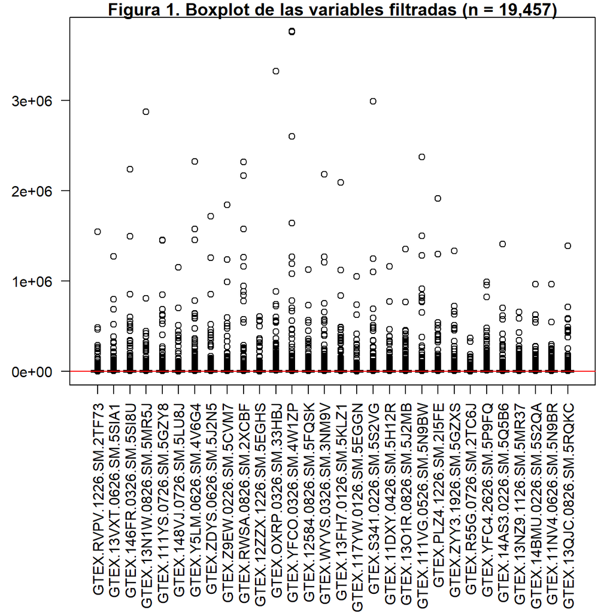

```r
> par(mar = c(13, 4, 1, 1))
>
> boxplot(dg_list$counts, las = 2, col = "lightblue", main = "Figura 1. Boxplot de las variables filtradas (n = 19,457)")
> abline(h = mean(dg_list$counts), col = "red")
```

Se utiliza el método TMM porque es el recomendado en la literatura (Rueda and Pereira 2015).

## Normalización

```r
> # Normalization
> dg_list <- calcNormFactors(dg_list, method = "TMM")
```

## Exploración de datos

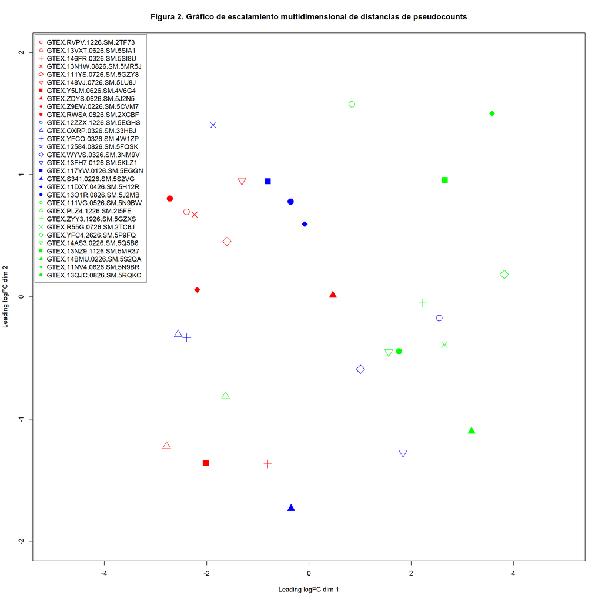

```r
> # Data Exploration
> plotMDS(dg_list, pch = c(1:6, 15, 17, 18, 19), col = c(rep("red",
+     10), rep("blue", 10), rep("green", 10)), cex = 2, main = "Figura 2. Gráfico de escalamiento multidimensional de distancias de pseudocounts",
+     xlim = c(-5, 5), ylim = c(-2, 2))
> legend(-5.36, 2.15, legend = count_colnames, pch = c(1:6, 15,
+     17, 18, 19), col = c(rep("red", 10), rep("blue", 10), rep("green",
+     10)))
```

```r
> # 3, 1.67
```

## Ajuste del modelo

Especificación de la matriz de diseño

```r
> # sample_type sample_replicate
>
> s_type <- as.character(less_targets$group)
> # s_rep <- paste('S', rep(1:3, each=10), sep = '')
>
> # length(s_type)==length(s_rep)
```

```r
> (design_mat <- model.matrix(~s_type))
```

```
   (Intercept) s_typeNIT s_typeSFI
1            1         1         0
2            1         1         0
3            1         1         0
4            1         1         0
5            1         1         0
6            1         1         0
7            1         1         0
8            1         1         0
9            1         1         0
10           1         1         0
11           1         0         1
12           1         0         1
13           1         0         1
14           1         0         1
```

[output cut: 21 more lines]

```r
> (design_mat_2 <- model.matrix(~0 + s_type))
```

```
   s_typeELI s_typeNIT s_typeSFI
1          0         1         0
2          0         1         0
3          0         1         0
4          0         1         0
5          0         1         0
6          0         1         0
7          0         1         0
8          0         1         0
9          0         1         0
10         0         1         0
11         0         0         1
12         0         0         1
13         0         0         1
14         0         0         1
```

[output cut: 21 more lines]

## Estimación de la dispersión:

`edgeR` utiliza un método empírico bayesiano para disminuir la estimación de la dispersión intergénica hacia la dispersión común (*tagwise*).

Es importante resaltar que debe estimarse la dispersión común y su tendencia antes de que podamos estimar la dispersión *tagwise*.

```r
> # here we lose the former dg_list is a Negative binomial
> # distribution is adequate for differential analysis?  check
> # doi: 10.1186/s12859-020-3506-x later
>
> dg_list_1 <- estimateGLMCommonDisp(dg_list, design = design_mat)
> dg_list_1 <- estimateGLMTrendedDisp(dg_list_1, design = design_mat)
> dg_list_1 <- estimateGLMTagwiseDisp(dg_list_1, design = design_mat)
>
> dg_list_2 <- estimateGLMCommonDisp(dg_list, design = design_mat_2)
> dg_list_2 <- estimateGLMTrendedDisp(dg_list_2, design = design_mat_2)
> dg_list_2 <- estimateGLMTagwiseDisp(dg_list_2, design = design_mat_2)
>
> dim(dg_list_1)
```

```
[1] 19457    30
```

```r
> dim(dg_list_2)
```

```
[1] 19457    30
```

```r
> short_names <- as.character(dg_list_2$samples$short_name)
> # ***
```

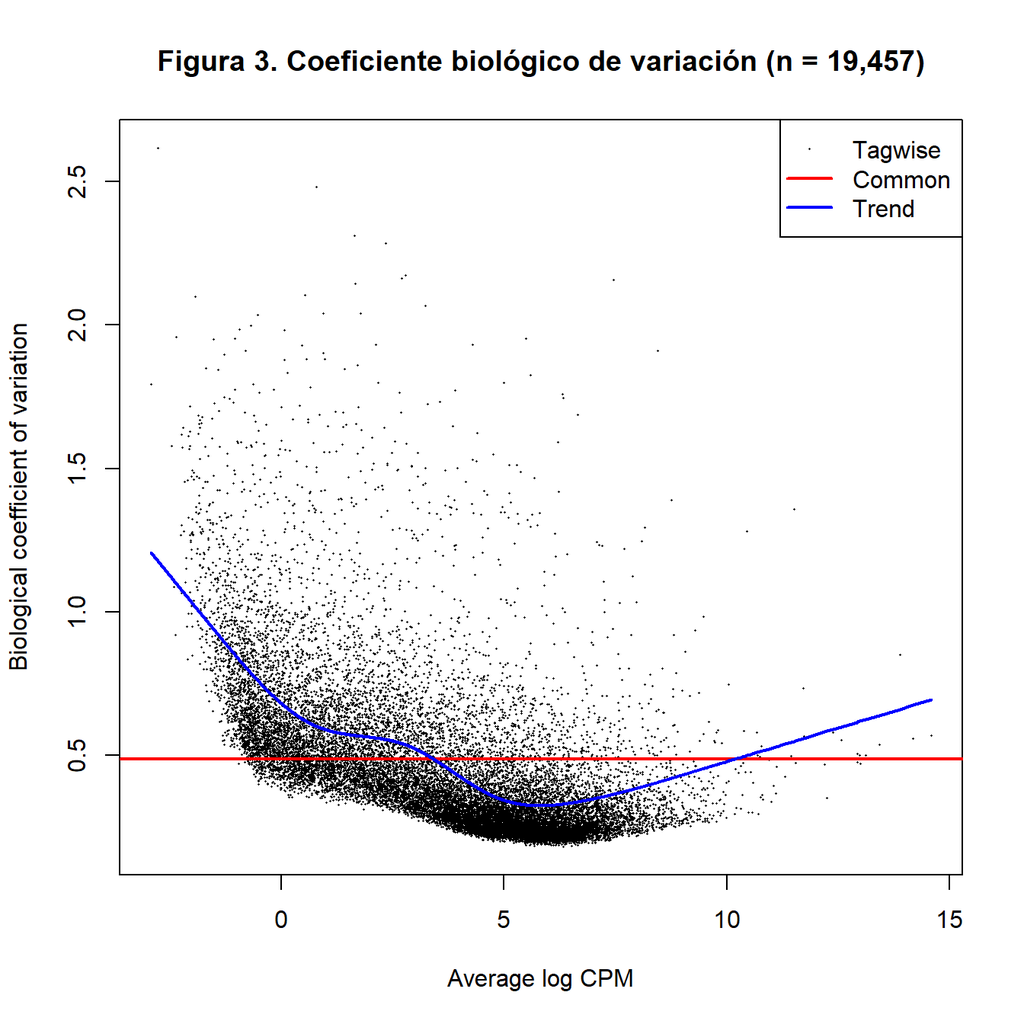

```r
> plotBCV(dg_list_1, main = "Figura 3. Coeficiente biológico de variación (n = 19,457)")
```

```r
> # plotBCV(dg_list_2,main='Figura 3. Coeficiente biológico de
> # variación (n = 19,457)')
```

## Expresión diferencial

```r
> fit_1 <- glmFit(dg_list_1, design_mat)
> lrt_1 <- glmLRT(fit_1, coef = 3)
> # no se utiliza glmQLFit() para no reescalar.
> # https://support.bioconductor.org/p/76790/
>
> fit_2 <- glmFit(dg_list_2, design_mat_2)
> lrt_2 <- glmLRT(fit_2, coef = 3)
```

```r
> edgeR_result_1 <- topTags(lrt_1)
> edgeR_result_2 <- topTags(lrt_2)
```

```r
> # save() didn't work, no clue why
> topTags_1 <- topTags(lrt_1, n = 19457)
> rownames(topTags_1$table) = 1:19457
> # save(topTags(lrt_1, n=19457)$table,
> # file='./results/edgeR_result.RData')
> write.csv(topTags_1$table, file = "./results/edgeR_result.csv")
```

```r
> head(topTags(lrt_1, n = 19457)$table)
```

```
                          genes     logFC   logCPM       LR       PValue
ENSG00000068831 ENSG00000068831 -2.936027 5.876179 63.86752 1.330738e-15
ENSG00000204282 ENSG00000204282 -2.658558 4.051656 60.08050 9.105593e-15
ENSG00000213654 ENSG00000213654 -2.175416 4.733496 54.12547 1.880875e-13
ENSG00000247982 ENSG00000247982 -2.999687 4.847406 52.83536 3.627114e-13
ENSG00000065357 ENSG00000065357 -2.058945 5.854238 52.51674 4.265966e-13
ENSG00000111913 ENSG00000111913 -2.400144 4.684510 52.29873 4.766826e-13
                         FDR
ENSG00000068831 2.589217e-11
ENSG00000204282 8.858376e-11
ENSG00000213654 1.219873e-09
ENSG00000247982 1.545802e-09
ENSG00000065357 1.545802e-09
ENSG00000111913 1.545802e-09
```

```r
> head(topTags(lrt_2, n = 19457)$table)
```

```
                          genes     logFC     logCPM       LR PValue FDR
ENSG00000263884 ENSG00000263884 -21.10449 -0.5153557 1712.634      0   0
ENSG00000230532 ENSG00000230532 -20.67314 -0.5093542 1556.693      0   0
ENSG00000254783 ENSG00000254783 -20.59149 -0.3009650 1674.608      0   0
ENSG00000263050 ENSG00000263050 -20.52344 -0.5051750 1575.975      0   0
ENSG00000229789 ENSG00000229789 -20.46110 -0.4749946 1512.508      0   0
ENSG00000225793 ENSG00000225793 -20.43667 -0.2137106 1612.663      0   0
```

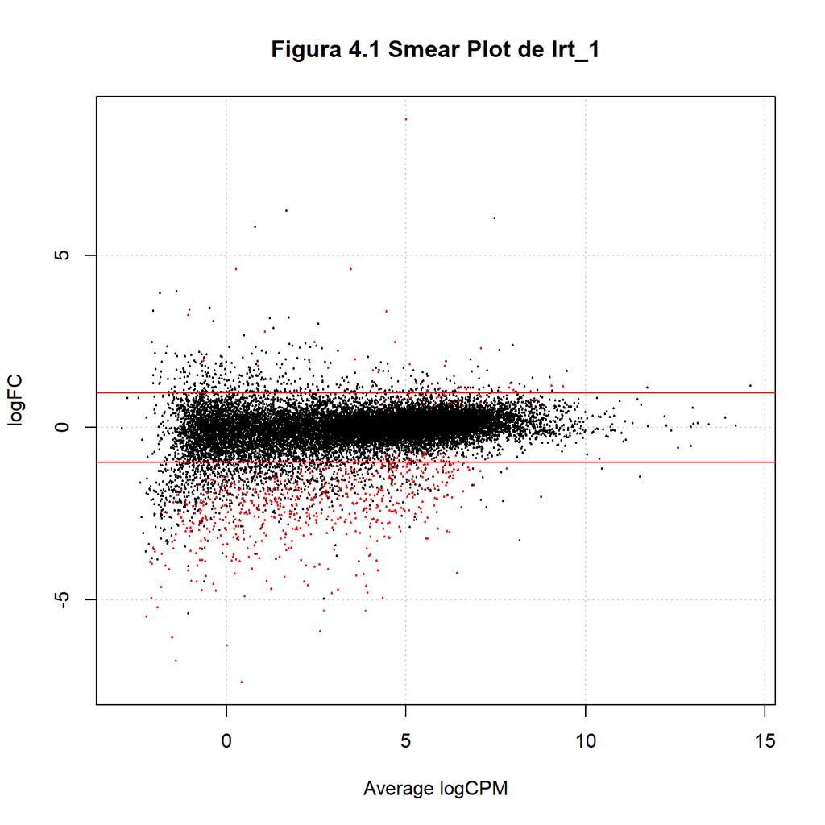

```r
> # Similar to a volcano plot.
> de_genes <- decideTests(lrt_1, p = 0.001)
> de_genes <- rownames(lrt_1)[as.logical(de_genes)]
> plotSmear(lrt_1, de.tags = de_genes, main = "Figura 4.1 Smear Plot de lrt_1")
> abline(h = c(-1, 1), col = 2)
```

```r
> # de_genes <- decideTests(lrt_2, p=0.001) de_genes <-
> # rownames(lrt_2)[as.logical(de_genes)] plotSmear(lrt_2,
> # de.tags=de_genes, main='Figura 4.2 Smear Plot de lrt_2')
> # abline(h=c(-1,1), col=2)
```

```r
> # contrastes
> design_mat_2 <- model.matrix(~0 + s_type)
> fit_2 <- glmFit(dg_list_2, design_mat_2)
>
> NITvsSFI <- glmLRT(fit_2, contrast = c(0, 1, -1))
> SFIvsELI <- glmLRT(fit_2, contrast = c(-1, 0, 1))
> NITvsELI <- glmLRT(fit_2, contrast = c(-1, 1, 0))
```

### Listas de Genes diferencialmente expresados

```r
> NITvsSFI_df <- as.data.frame(topTags(NITvsSFI))
> SFIvsELI_df <- as.data.frame(topTags(SFIvsELI))
> NITvsELI_df <- as.data.frame(topTags(NITvsELI))
>
> # dim(NITvsSFI_df)
```

### Colocación de anotaciones a los resultados de `edgeR`

```r
> # dim(NITvsSFI) dim(SFIvsELI) dim(NITvsELI)
```

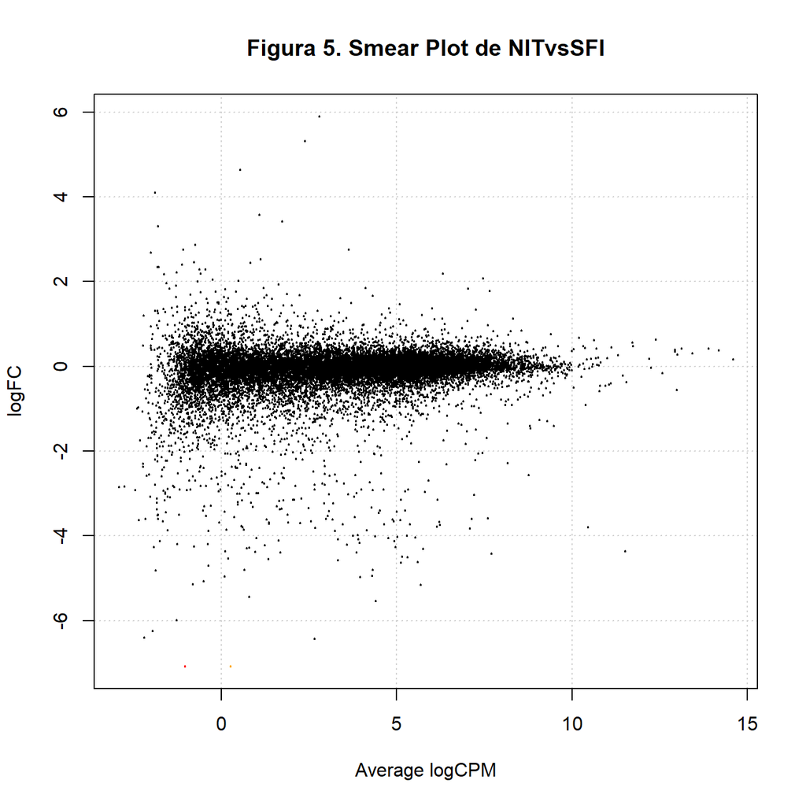

```r
> de_g1 <- decideTests(NITvsSFI, p = 0.001)
> de_g1 <- rownames(NITvsSFI)[as.logical(de_g1)]
> plotSmear(NITvsSFI, de.tags = de_g1, main = "Figura 5. Smear Plot de NITvsSFI")
```

```r
> # abline(h=c(-1,1), col=2)
```

Al parecer hay muy pocas diferencias de expresión entre las condiciones de no infiltración (NIT) e infiltrados pequeños focales (SFI)

```r
> # de_genes <- decideTests(lrt, p=0.001) de_genes <-
> # rownames(lrt)[as.logical(de_genes)] plotSmear(lrt,
> # de.tags=de_genes, main='Figura 4. Smear Plot')
> # abline(h=c(-1,1), col=2)
```

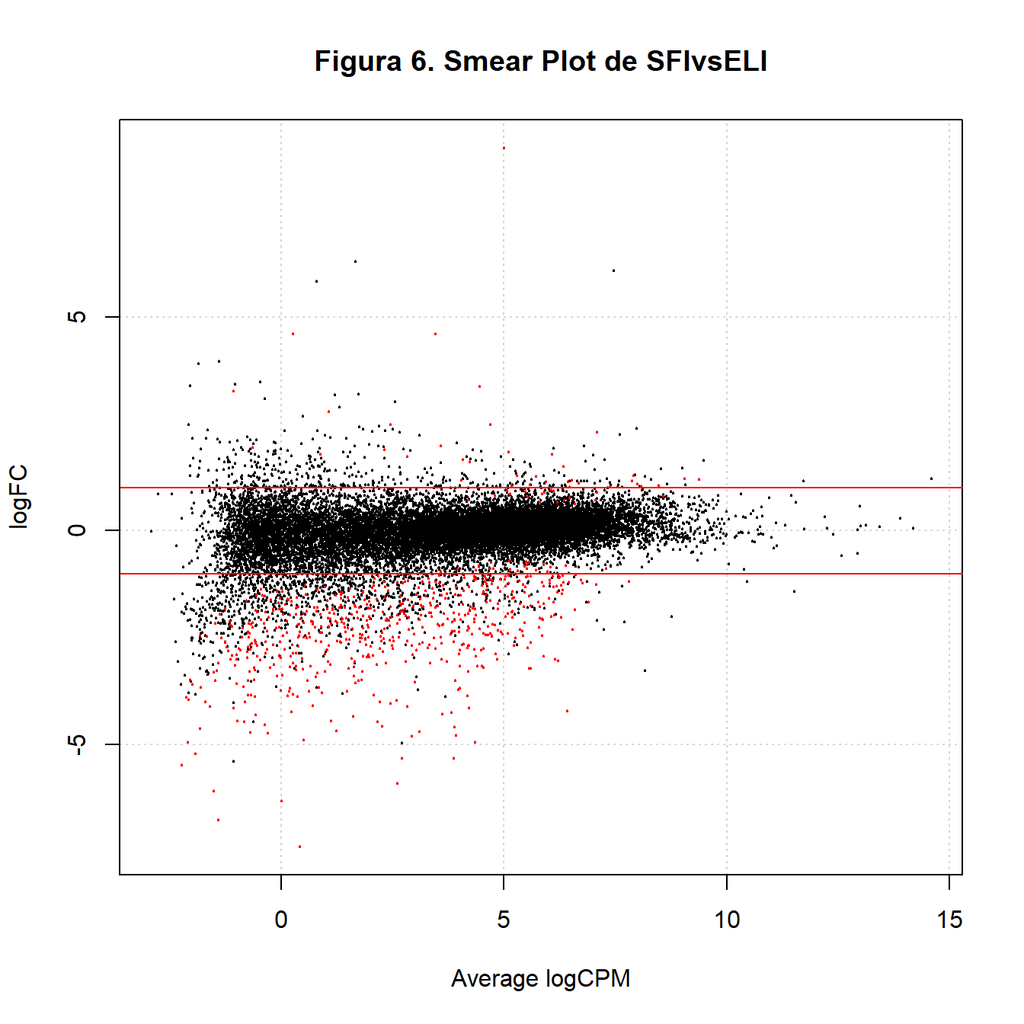

```r
> de_g2 <- decideTests(SFIvsELI, p = 0.001)
> de_g2 <- rownames(SFIvsELI)[as.logical(de_g2)]
> plotSmear(SFIvsELI, de.tags = de_g2, main = "Figura 6. Smear Plot de SFIvsELI")
> abline(h = c(-1, 1), col = 2)
```

Parece ser que SFI se expresa a niveles más bajos que ELI

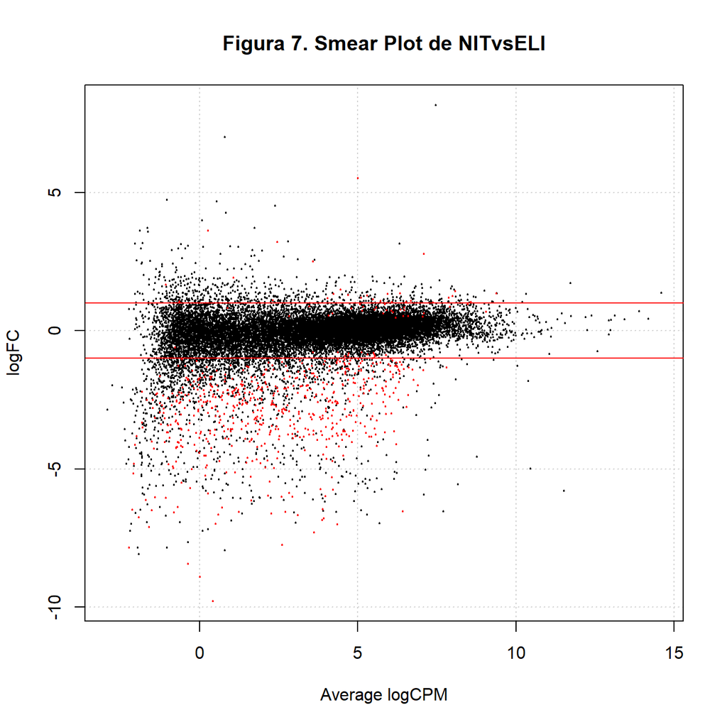

```r
> de_g3 <- decideTests(NITvsELI, p = 0.001)
> de_g3 <- rownames(NITvsELI)[as.logical(de_g3)]
> plotSmear(NITvsELI, de.tags = de_g2, main = "Figura 7. Smear Plot de NITvsELI")
> abline(h = c(-1, 1), col = 2)
```

Parece ser que NIT se expresa a niveles más bajos que ELI

## Anotación

```r
> # [enlace](https://bioinformatics-core-shared-training.github.io/RNAseq-R/
> # rna-seq-annotation-visualisation.nb.html)
> library(org.Hs.eg.db)
> columns(org.Hs.eg.db)
```

```
 [1] "ACCNUM"       "ALIAS"        "ENSEMBL"      "ENSEMBLPROT"  "ENSEMBLTRANS"
 [6] "ENTREZID"     "ENZYME"       "EVIDENCE"     "EVIDENCEALL"  "GENENAME"
[11] "GO"           "GOALL"        "IPI"          "MAP"          "OMIM"
[16] "ONTOLOGY"     "ONTOLOGYALL"  "PATH"         "PFAM"         "PMID"
[21] "PROSITE"      "REFSEQ"       "SYMBOL"       "UCSCKG"       "UNIGENE"
[26] "UNIPROT"
```

```r
> library(AnnotationDbi)
> keytypes(org.Hs.eg.db)
```

```
 [1] "ACCNUM"       "ALIAS"        "ENSEMBL"      "ENSEMBLPROT"  "ENSEMBLTRANS"
 [6] "ENTREZID"     "ENZYME"       "EVIDENCE"     "EVIDENCEALL"  "GENENAME"
[11] "GO"           "GOALL"        "IPI"          "MAP"          "OMIM"
[16] "ONTOLOGY"     "ONTOLOGYALL"  "PATH"         "PFAM"         "PMID"
[21] "PROSITE"      "REFSEQ"       "SYMBOL"       "UCSCKG"       "UNIGENE"
[26] "UNIPROT"
```

```r
> # head(keys(org.Hs.eg.db, keytype = 'ENSEMBL'))
> # head(dg_list$genes$genes)
>
> my_keys <- dg_list$genes$genes
>
> # Verifies whether my keys are in the database
> table(my_keys %in% keys(org.Hs.eg.db, keytype = "ENSEMBL"))
```

```
FALSE  TRUE
 2989 16468
```

Hay 2989 genes que no están en la base de datos. Sin embargo, continuaremos con el procedimiento de anotación.

```r
> library(org.Hs.eg.db)
> library(ensembldb)
>
> annotation_na <- select(org.Hs.eg.db, keys = my_keys, columns = c("ENSEMBL",
+     "SYMBOL", "GENENAME"), keytype = "ENSEMBL")
> tail(annotation_na)
```

```
              ENSEMBL SYMBOL                                   GENENAME
19576 ENSG00000212907   ND4L NADH dehydrogenase, subunit 4L (complex I)
19577 ENSG00000198886    ND4  NADH dehydrogenase, subunit 4 (complex I)
19578 ENSG00000198786    ND5  NADH dehydrogenase, subunit 5 (complex I)
19579 ENSG00000198695    ND6  NADH dehydrogenase, subunit 6 (complex I)
19580 ENSG00000210194   <NA>                                       <NA>
19581 ENSG00000198727   CYTB                               cytochrome b
```

```r
> dim(annotation_na)
```

```
[1] 19581     3
```

Se comprobó que había 124 códigos de ENSEMBL repetidos, que fueron eliminados de la siguiente forma:

```r
> # Se sacó del código para no cargar dplyr library(dplyr)
>
> # datos repetidos a <- distinct(annotation_na, ENSEMBL)
>
> # annotation_na%>%distinct(ENSEMBL, .keep_all=T)
> # detach('package:dplyr', unload=TRUE)
>
> # unique no sirvió library(base) annotation_na <-
> # unique(annotation_na)
>
> repetidos <- which(duplicated(annotation_na$ENSEMBL) == T)
>
> annotation_na <- annotation_na[-repetidos, ]
>
> dim(annotation_na)
```

```
[1] 19457     3
```

Nótese que el dataset de anotaciones tiene 2989 `NA`.

```r
> # table(NITvsSFI$genes$genes == annotation_na$ENSEMBL) didn't
> # work, can't explain why
>
> table(NITvsSFI$genes$genes %in% keys(org.Hs.eg.db, keytype = "ENSEMBL"))
```

```
FALSE  TRUE
 2989 16468
```

```r
> table(annotation_na$ENSEMBL %in% keys(org.Hs.eg.db, keytype = "ENSEMBL"))
```

```
FALSE  TRUE
 2989 16468
```

```r
> table(annotation_na$ENSEMBL %in% NITvsSFI$genes$genes)
```

```
 TRUE
19457
```

```r
> length(annotation_na$ENSEMBL)
```

```
[1] 19457
```

```r
> length(NITvsSFI$genes$genes)
```

```
[1] 19457
```

Se utilizó [g:Profiler](https://biit.cs.ut.ee/gprofiler/convert) para conseguir los datos de los genes con `NA`. En algunos casos la descripción del gen se observa como número, que corresponde a HGNC (Ejemplo: `WASP family homolog 7, pseudogene [Source:HGNC Symbol;Acc:HGNC:38034]` )

```r
> na_idx <- which(is.na(annotation_na$SYMBOL) == TRUE)
>
> write.csv(annotation_na[na_idx, 1], file = "./results/anotaciones_con_na.csv")
>
> ids_na <- read.csv("./data/missing_data_for_annotation_na.csv",
+     header = TRUE, sep = ",")
>
> levels <- levels(ids_na$description)
>
> ann <- annotation_na
>
> ann$SYMBOL[na_idx] <- as.character(ids_na$name)
>
> ann$GENENAME[na_idx] <- as.character(levels)
```

Se puede observar que ahora todos los datos cuentan con información asociada

```r
> length(which(is.na(ann$ENSEMBL) == T))
```

```
[1] 0
```

Sin embargo, quedan 585 casos sin información

```r
> length(which(ann$SYMBOL == "None"))
```

```
[1] 585
```

Se ajusta el p-valor por la tasa de descubrimiento falso:

```r
> NITvsSFI$table$PValue <- p.adjust(NITvsSFI$table$PValue, "fdr")
> SFIvsELI$table$PValue <- p.adjust(SFIvsELI$table$PValue, "fdr")
> NITvsELI$table$PValue <- p.adjust(NITvsELI$table$PValue, "fdr")
```

```r
> res_ann_NITvsSFI <- cbind(NITvsSFI, ann)
> res_ann_SFIvsELI <- cbind(SFIvsELI, ann)
> res_ann_NITvsELI <- cbind(NITvsELI, ann)
```

```r
> res_ann_NITvsSFI_ordered <- res_ann_NITvsSFI[order(res_ann_NITvsSFI$PValue),
+     ]
> res_ann_SFIvsELI_ordered <- res_ann_SFIvsELI[order(res_ann_SFIvsELI$PValue),
+     ]
> res_ann_NITvsELI_ordered <- res_ann_NITvsELI[order(res_ann_NITvsELI$PValue),
+     ]
>
> write.csv(res_ann_NITvsSFI_ordered, file = "./results/res_ann_NITvsSFI.csv")
> write.csv(res_ann_SFIvsELI_ordered, file = "./results/res_ann_SFIvsELI.csv")
> write.csv(res_ann_NITvsELI_ordered, file = "./results/res_ann_NITvsELI.csv")
```

```r
> head(res_ann_NITvsSFI_ordered)
```

```
                genes     logFC     logCPM       LR       PValue
18500 ENSG00000254030 -6.707659 -1.0448469 34.33608 9.022316e-05
2544  ENSG00000211619 -6.923504  0.2563982 24.00670 3.219686e-03
9128  ENSG00000041982 -3.580927  7.5856807 23.64521 3.219686e-03
10233 ENSG00000117983  5.322774  2.3814132 25.66194 3.219686e-03
13197 ENSG00000211892 -4.418972  7.6960572 23.71605 3.219686e-03
13207 ENSG00000265714 -6.252778 -1.9641107 23.73321 3.219686e-03
              ENSEMBL SYMBOL
18500 ENSG00000254030  IGLC5
2544  ENSG00000211619   None
9128  ENSG00000041982    TNC
10233 ENSG00000117983  MUC5B
13197 ENSG00000211892  IGHG4
13207 ENSG00000265714   None
                                                                                     GENENAME
18500                                                   novel transcript, overlapping to TSKU
2544  immunoglobulin kappa variable 1-39 (gene/pseudogene) [Source:HGNC Symbol;Acc:HGNC:5740]
9128                                                                               tenascin C
10233                                                  mucin 5B, oligomeric mucus/gel-forming
13197   Fc fragment of IgG receptor IIc (gene/pseudogene) [Source:HGNC Symbol;Acc:HGNC:15626]
13207                  ferritin heavy chain 1 pseudogene 7 [Source:HGNC Symbol;Acc:HGNC:3994]
```

```r
> head(res_ann_SFIvsELI_ordered)
```

```
                genes     logFC   logCPM       LR       PValue         ENSEMBL
10671 ENSG00000068831 -2.936027 5.876179 63.86752 2.589217e-11 ENSG00000068831
15890 ENSG00000204282 -2.658558 4.051656 60.08050 8.858376e-11 ENSG00000204282
6350  ENSG00000213654 -2.175416 4.733496 54.12547 1.219873e-09 ENSG00000213654
6151  ENSG00000111913 -2.400144 4.684510 52.29873 1.545802e-09 ENSG00000111913
11735 ENSG00000065357 -2.058945 5.854238 52.51674 1.545802e-09 ENSG00000065357
13562 ENSG00000247982 -2.999687 4.847406 52.83536 1.545802e-09 ENSG00000247982
          SYMBOL                                             GENENAME
10671    RASGRP2                       RAS guanyl releasing protein 2
15890 TNRC6C-AS1                               TNRC6C antisense RNA 1
6350       GPSM3                      G protein signaling modulator 3
6151      RIPOR2 RHO family interacting cell polarization regulator 2
11735       DGKA                          diacylglycerol kinase alpha
13562  LINC00926           long intergenic non-protein coding RNA 926
```

```r
> head(res_ann_NITvsELI_ordered)
```

```
                genes     logFC   logCPM       LR       PValue         ENSEMBL
15890 ENSG00000204282 -3.167405 4.051656 81.52675 3.364224e-15 ENSG00000204282
14977 ENSG00000072818 -3.546875 5.529016 77.77200 7.725139e-15 ENSG00000072818
16699 ENSG00000105122 -3.187212 5.402915 77.71372 7.725139e-15 ENSG00000105122
15809 ENSG00000172794 -3.898037 2.933646 76.62524 1.005350e-14 ENSG00000172794
16465 ENSG00000205744 -2.870828 4.855462 73.95432 3.111019e-14 ENSG00000205744
6350  ENSG00000213654 -2.563641 4.733496 72.91402 3.464922e-14 ENSG00000213654
          SYMBOL                                                 GENENAME
15890 TNRC6C-AS1                                   TNRC6C antisense RNA 1
14977      ACAP1 ArfGAP with coiled-coil, ankyrin repeat and PH domains 1
16699     RASAL3                             RAS protein activator like 3
15809      RAB37                        RAB37, member RAS oncogene family
16465    DENND1C                                DENN domain containing 1C
6350       GPSM3                          G protein signaling modulator 3
```

```r
> summary(de1 <- decideTestsDGE(NITvsSFI, adjust.method = "fdr"))
```

```
       1*s_typeNIT -1*s_typeSFI
Down                          0
NotSig                    19457
Up                            0
```

```r
> summary(de2 <- decideTestsDGE(SFIvsELI, adjust.method = "fdr"))
```

```
       -1*s_typeELI 1*s_typeSFI
Down                        687
NotSig                    18681
Up                           89
```

```r
> summary(de3 <- decideTestsDGE(NITvsELI, adjust.method = "fdr"))
```

```
       -1*s_typeELI 1*s_typeNIT
Down                       1775
NotSig                    17157
Up                          525
```

```r
> # Different maps
>
> # detags <- rownames(NITvsSFI)[as.logical(de1)]
> # plotSmear(NITvsSFI, de.tags=detags, main='Smear plot de
> # NITvsSFI')
>
>
> # detags_2 <- rownames(SFIvsELI)[as.logical(de2)]
> # plotSmear(SFIvsELI, de.tags=detags_2, main='Smear plot de
> # SFIvsELI')
>
>
> # detags_3 <- rownames(NITvsELI)[as.logical(de3)]
> # plotSmear(NITvsELI, de.tags=detags_2, main='Smear plot de
> # NITvsELI')
```

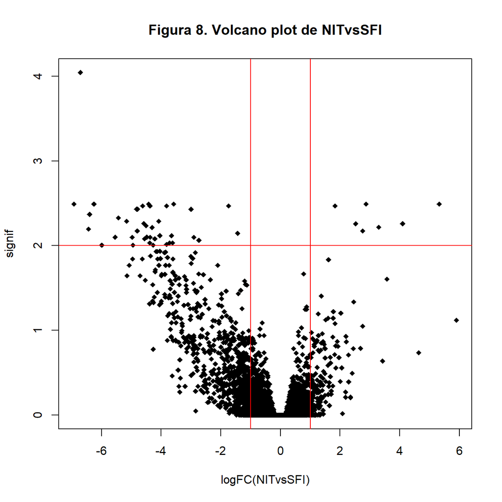

```r
> detags <- rownames(NITvsSFI)[as.logical(de1)]
> signif <- -log10(res_ann_NITvsSFI$PValue)
> plot(res_ann_NITvsSFI$logFC, signif, pch = 18, xlab = "logFC(NITvsSFI)",
+     main = "Figura 8. Volcano plot de NITvsSFI")
> points(res_ann_NITvsSFI[detags, "logFC"], -log10(res_ann_NITvsSFI[detags,
+     "PValue"]), pch = 16, col = "lightblue")
> abline(h = 2, v = c(-1, 1), col = 2)
```

[figure not shown]

```r
> detags <- rownames(SFIvsELI)[as.logical(de2)]
> signif <- -log10(res_ann_SFIvsELI$PValue)
> plot(res_ann_SFIvsELI$logFC, signif, pch = 18, xlab = "logFC(NITvsSFI)",
+     main = "Figura 9. Volcano plot de SFIvsELI")
> points(res_ann_SFIvsELI[detags, "logFC"], -log10(res_ann_SFIvsELI[detags,
+     "PValue"]), pch = 16, col = "lightblue")
> abline(h = 2, v = c(-1, 1), col = 2)
```

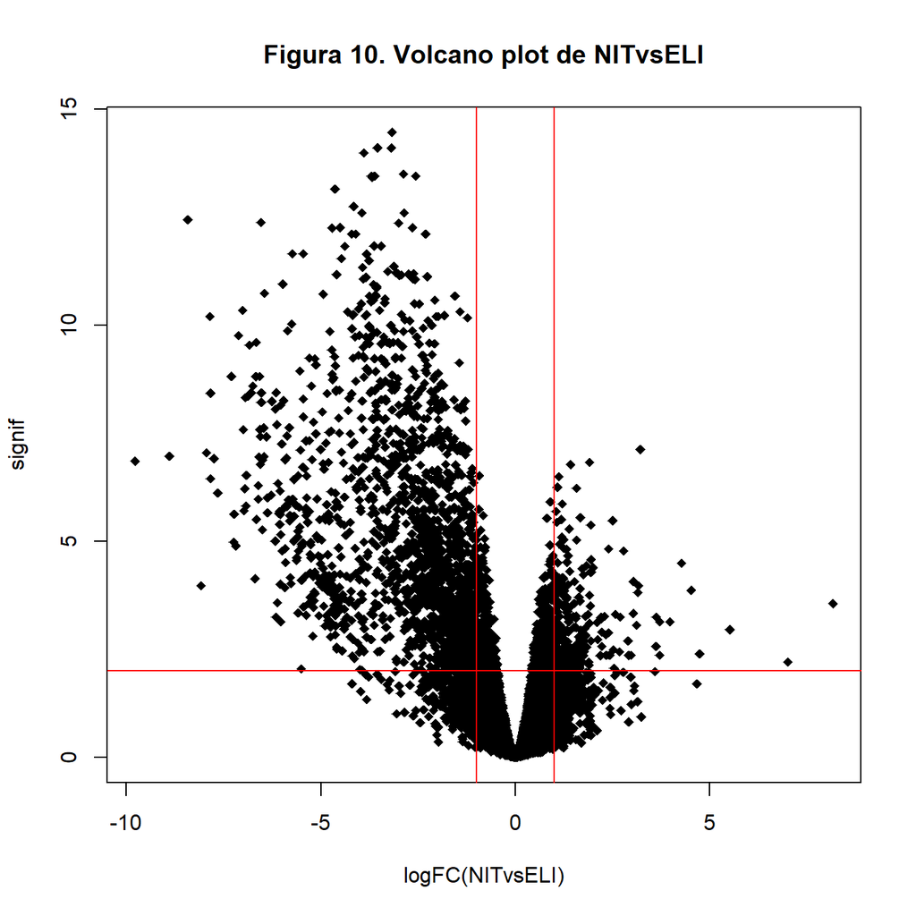

```r
> detags <- rownames(NITvsELI)[as.logical(de3)]
> signif <- -log10(res_ann_NITvsELI$PValue)
> plot(res_ann_NITvsELI$logFC, signif, pch = 18, xlab = "logFC(NITvsELI)",
+     main = "Figura 10. Volcano plot de NITvsELI")
> points(res_ann_NITvsELI[detags, "logFC"], -log10(res_ann_NITvsELI[detags,
+     "PValue"]), pch = 16, col = "lightblue")
> abline(h = 2, v = c(-1, 1), col = 2)
```

```r
> length(de_g1)
```

```
[1] 1
```

```r
> length(de_g2)
```

```
[1] 653
```

```r
> length(de_g3)
```

```
[1] 1610
```

# Distribución de los datos

```r
> # [enlace](http://www.nathalievialaneix.eu/doc/html/solution-edgeR-rnaseq.html)
> library(mixOmics)
> # dge <- DGEList()
>
> # raw_count_table is dg_list_2$counts
>
>
> pseudocounts <- log2(dg_list_2$counts + 1)
> dim(pseudocounts)
```

```
[1] 19457    30
```

## Boxplots

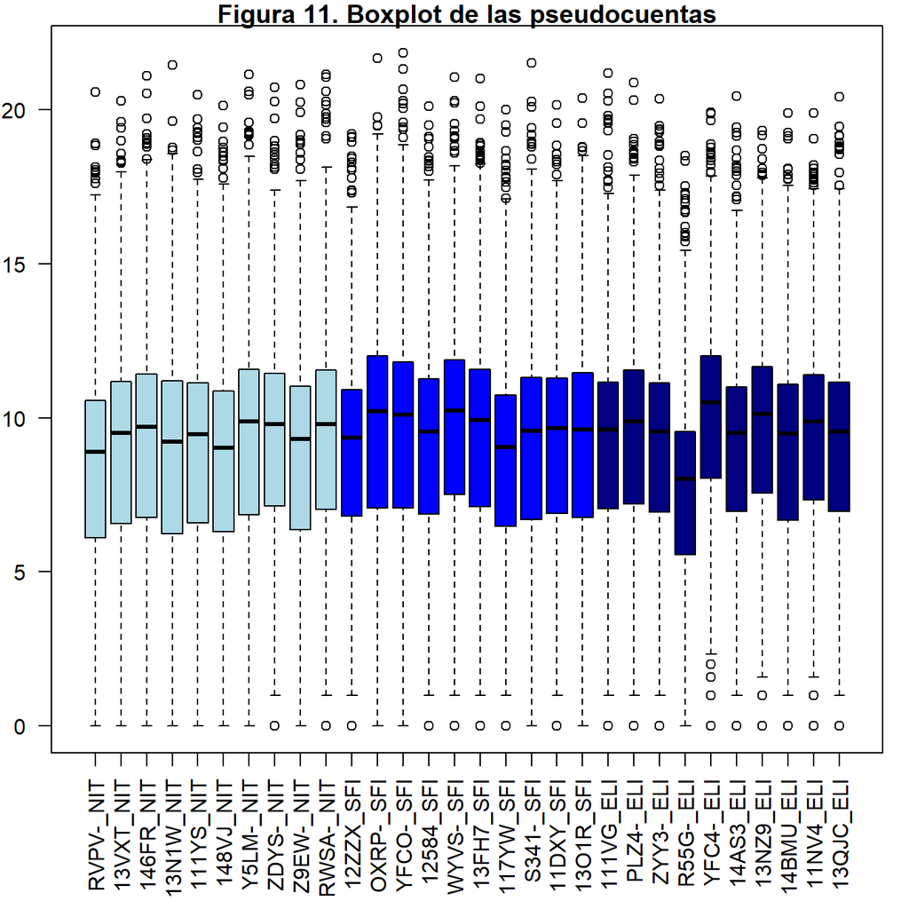

```r
> par(mar = c(6, 2, 1, 1))
>
> # long names colnames(pseudocounts) <-
> # colnames(dg_list_2$counts)
>
> # short names
> colnames(pseudocounts) <- as.character(dg_list_2$samples$short_name)
>
> boxplot(pseudocounts, las = 2, col = (c(rep("lightblue", 10),
+     rep("blue", 10), rep("navyblue", 10))), main = "Figura 11. Boxplot de las pseudocuentas")
```

## MA plots

```r
> library(reshape)
> m_NIT <- melt(pseudocounts[, 1:10])
> m_SFI <- melt(pseudocounts[, 11:20])
> m_ELI <- melt(pseudocounts[, 21:30])
```

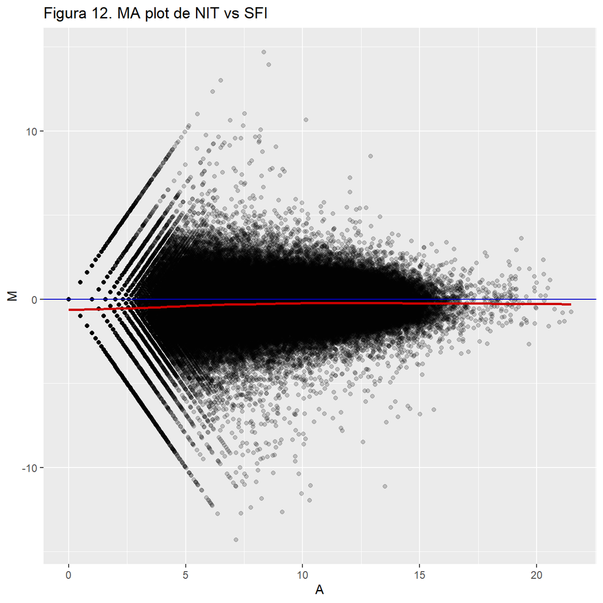

```r
> # NIT vs SFI
> x = m_NIT$value
> y = m_SFI$value
>
> # M-values
> M = x - y
>
> # A-values
> A = (x + y)/2
>
> df_ma = data.frame(A, M)
>
> ggplot(df_ma, aes(x = A, y = M)) + geom_point(size = 1.5, alpha = 1/5) +
+     geom_hline(color = "blue3", yintercept = 0) + stat_smooth(se = FALSE,
+     method = "loess", color = "red3") + ggtitle("Figura 12. MA plot de NIT vs SFI")
```

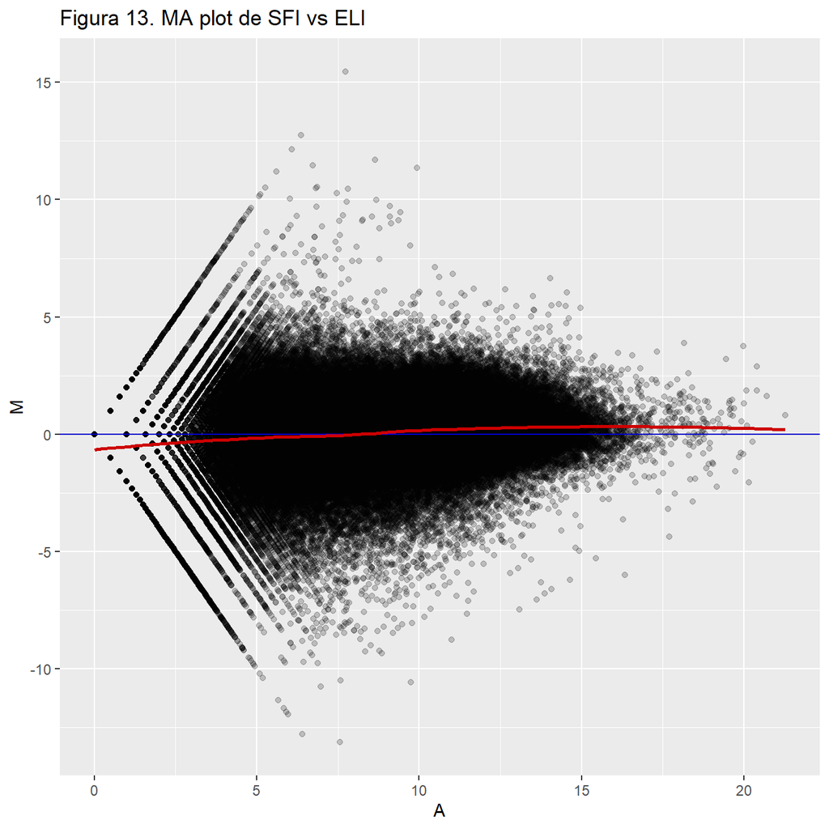

```r
> # SFI vs ELI
> x = m_SFI$value
> y = m_ELI$value
>
> # M-values
> M = x - y
>
> # A-values
> A = (x + y)/2
>
> df_ma = data.frame(A, M)
>
> ggplot(df_ma, aes(x = A, y = M)) + geom_point(size = 1.5, alpha = 1/5) +
+     geom_hline(color = "blue3", yintercept = 0) + stat_smooth(se = FALSE,
+     method = "loess", color = "red3") + ggtitle("Figura 13. MA plot de SFI vs ELI")
```

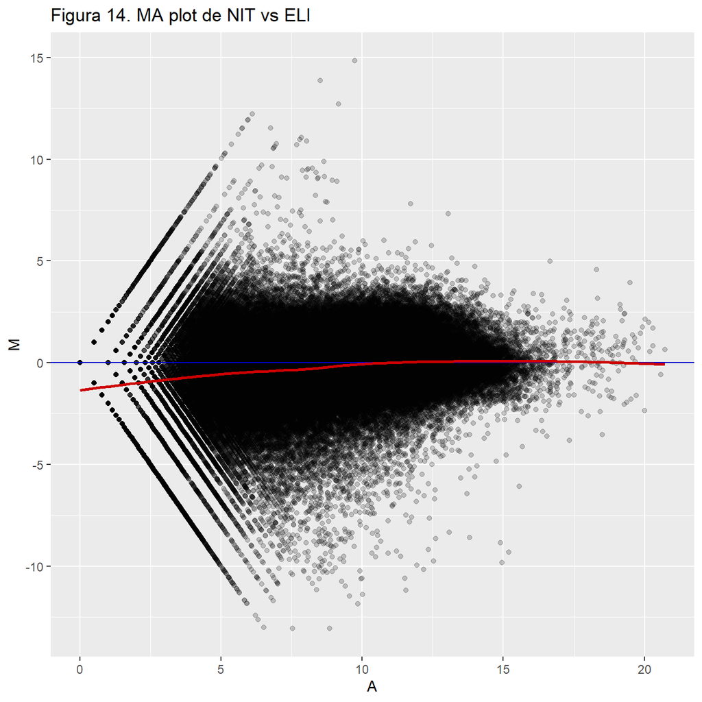

```r
> # NIT vs ELI
> x = m_NIT$value
> y = m_ELI$value
>
> # M-values
> M = x - y
>
> # A-values
> A = (x + y)/2
>
> df_ma = data.frame(A, M)
>
> ggplot(df_ma, aes(x = A, y = M)) + geom_point(size = 1.5, alpha = 1/5) +
+     geom_hline(color = "blue3", yintercept = 0) + stat_smooth(se = FALSE,
+     method = "loess", color = "red3") + ggtitle("Figura 14. MA plot de NIT vs ELI")
```

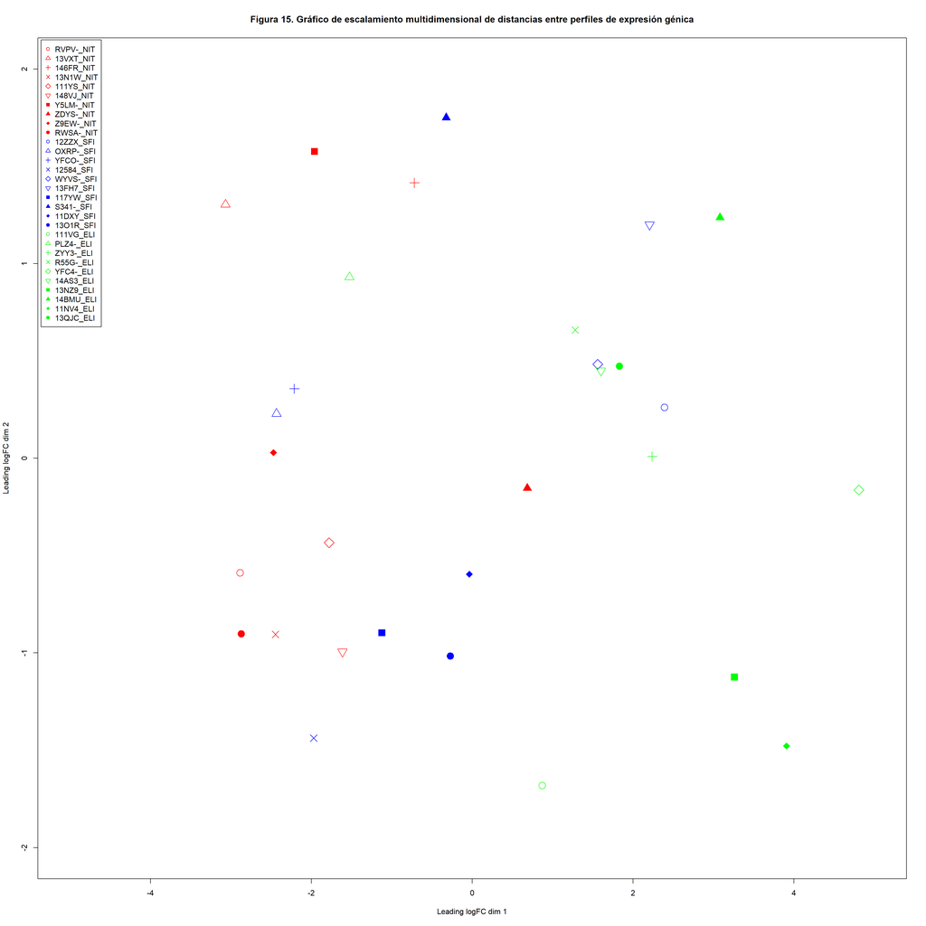

```r
> plotMDS(pseudocounts, pch = c(1:6, 15, 17, 18, 19), col = c(rep("red",
+     10), rep("blue", 10), rep("green", 10)), cex = 2, main = "Figura 15. Gráfico de escalamiento multidimensional de distancias entre perfiles de expresión génica",
+     xlim = c(-5, 5), ylim = c(-2, 2))
> legend(-5.36, 2.15, legend = dg_list_2$samples$short_name, pch = c(1:6,
+     15, 17, 18, 19), col = c(rep("red", 10), rep("blue", 10),
+     rep("green", 10)))
```

## Heatmaps (Clustering)

los heatmaps se realizaron de acuerdo a la literatura (Chen, Lun, and Smyth 2020).

### Para observar las distancias entre muestras

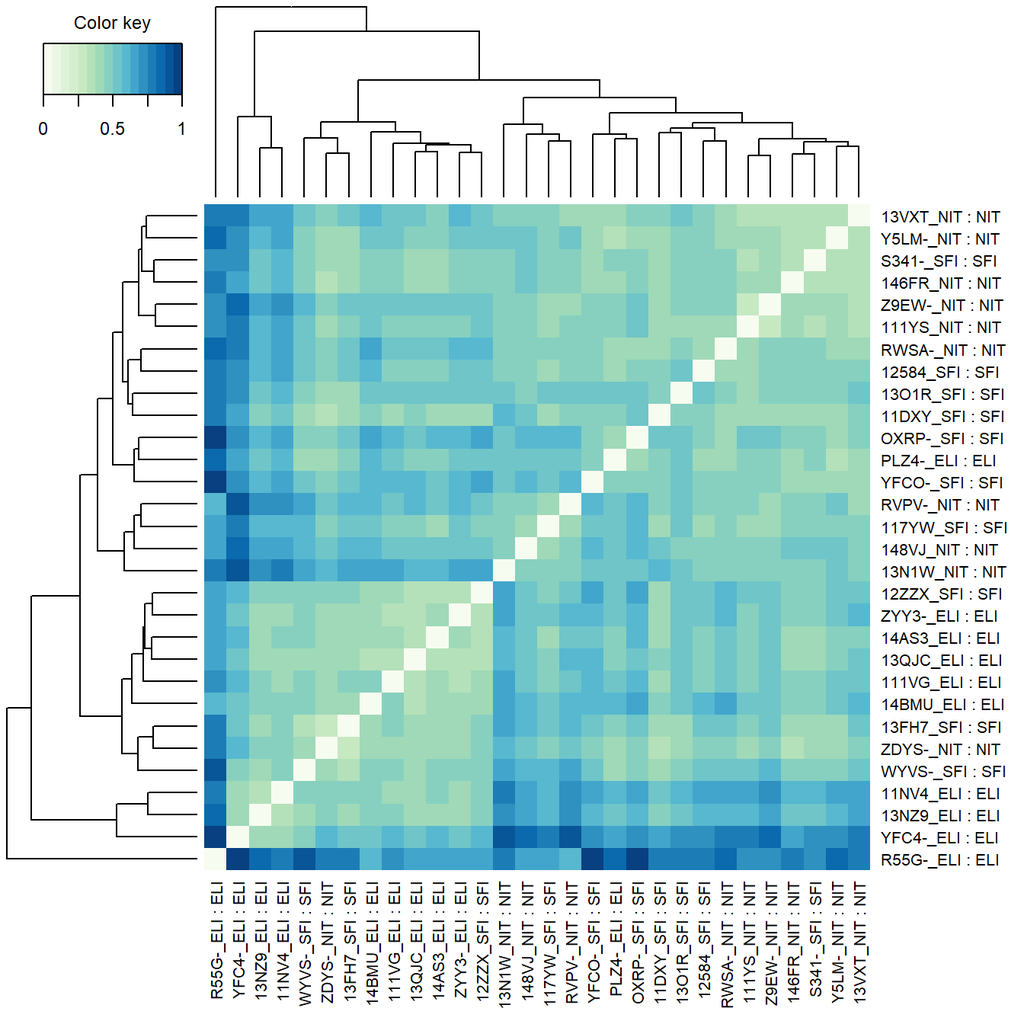

```r
> library(RColorBrewer)
> mat_dist <- pseudocounts
>
> group <- c(rep("NIT", 10), rep("SFI", 10), rep("ELI", 10))
>
> colnames(mat_dist) = paste(as.character(dg_list_2$samples$short_name),
+     group, sep = " : ")
>
> mat_dist <- as.matrix(dist(t(mat_dist)))
>
> mat_dist <- mat_dist/max(mat_dist)
>
> hmcol <- colorRampPalette(brewer.pal(9, "GnBu"))(16)
>
> cim(mat_dist, color = sort(hmcol, decreasing = T), symkey = FALSE,
+     margins = c(7, 7))
```

### Inferencia: decidir cuáles genes están diferencialmente expresados

```r
> # *** DESeq2 analysis example ~p59 Statistical analysis of
> # RNA-seq data
```

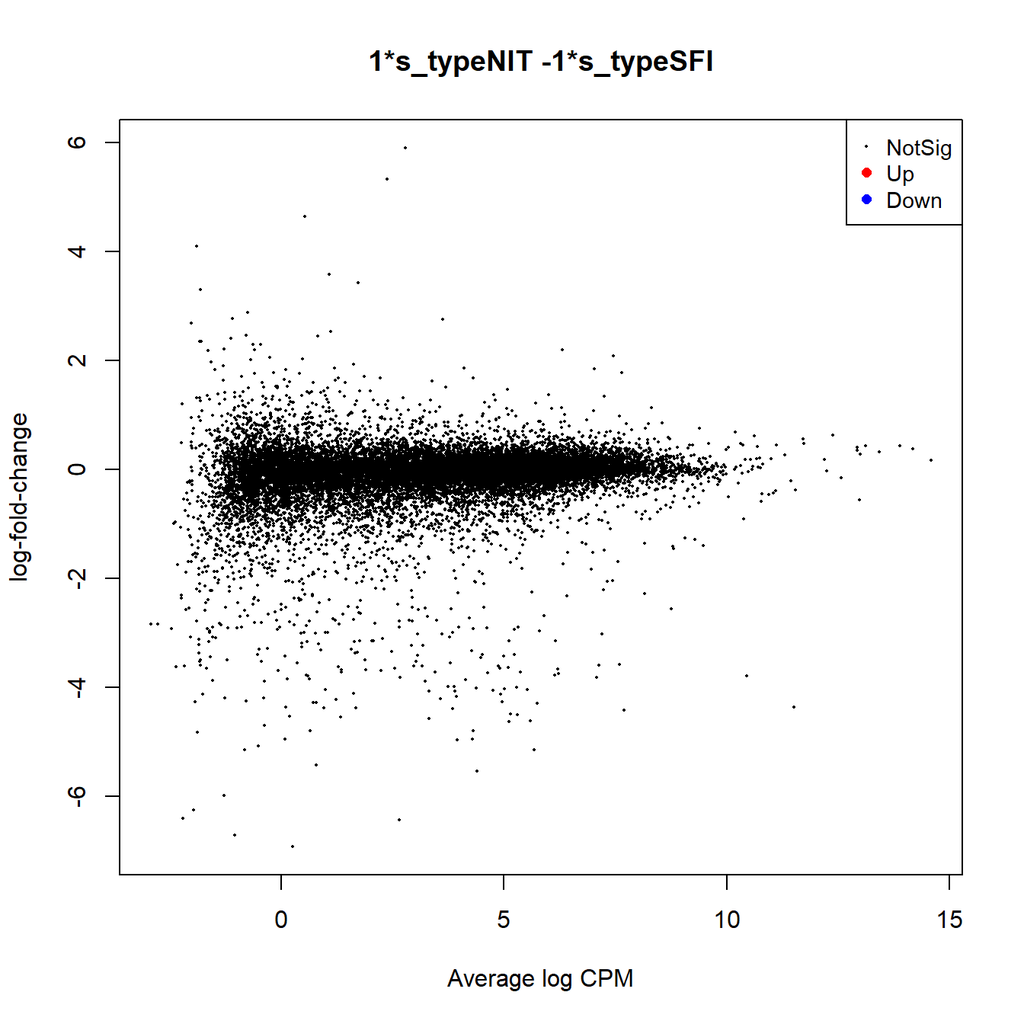

```r
> # Mean difference plot
> plotMD(NITvsSFI, status = de1)
```

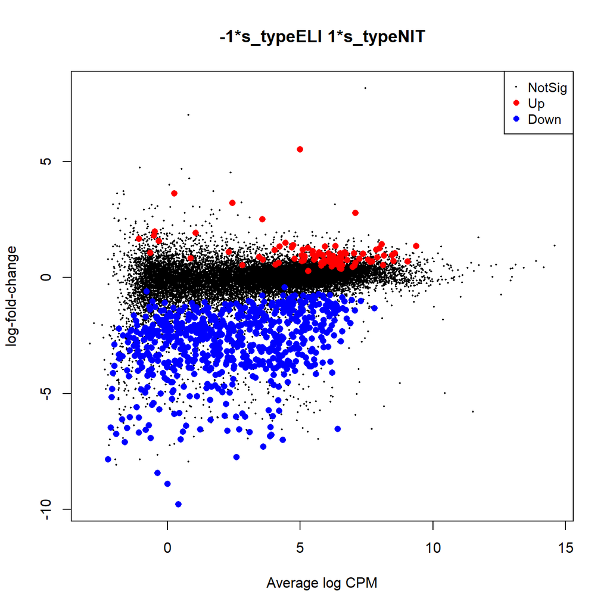

```r
> plotMD(NITvsELI, status = de2)
```

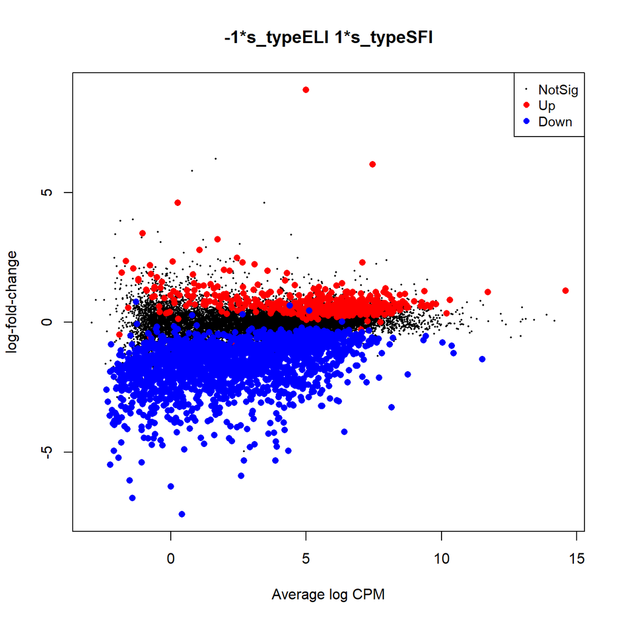

```r
> plotMD(SFIvsELI, status = de3)
```

### Expresión diferencial sobre un umbral específico (2x)

Es importante notar que los genes no se ordenan específicamente por pvalor, sino de acuerdo al dendrograma que los agrupa.

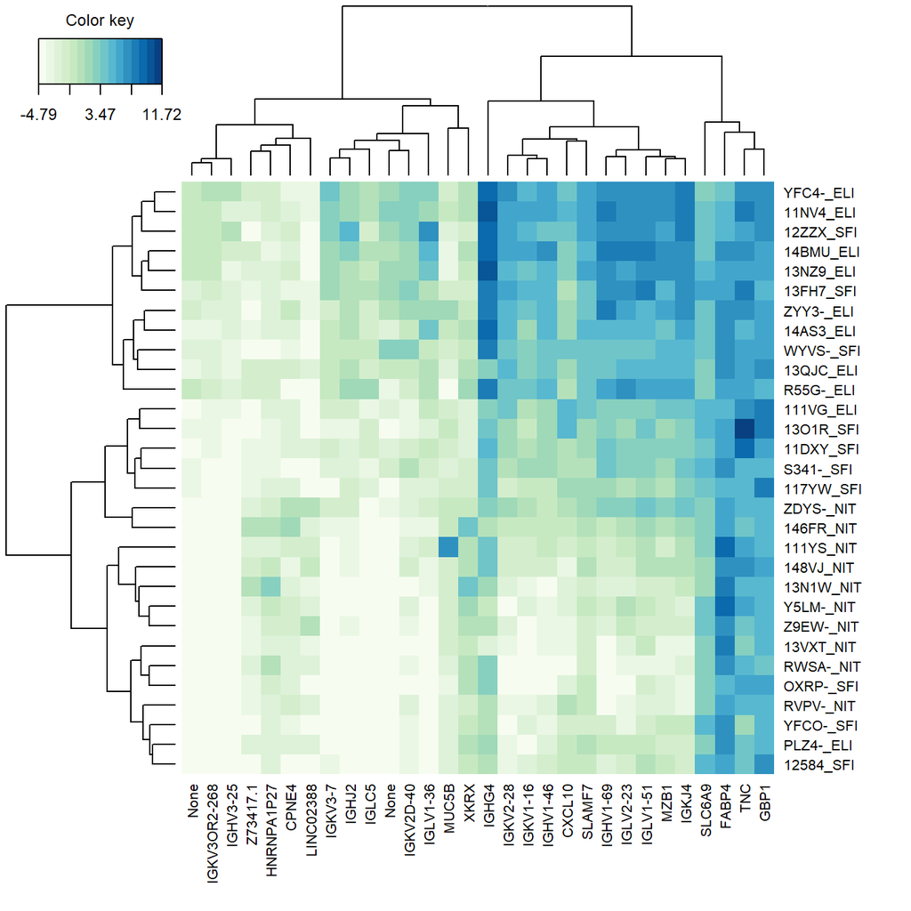

```r
> # NITvsSFI
>
> # Se anotaron los SYMBOL de los genes que salen como 'none'
> # se hizo ann$SYMBOL[o[n]] para cada n que fuese igual a none
>
> logCPM <- cpm(dg_list_2, prior.count = 2, log = T)
>
> rownames(logCPM) <- res_ann_NITvsSFI$SYMBOL
>
> colnames(logCPM) <- as.character(dg_list_2$samples$short_name)
>
> o <- order(res_ann_NITvsSFI$PValue)
>
> logCPM <- logCPM[o[1:30], ]
>
> # coolmap(logCPM, margins=c(7,7), lhei=c(1,6), lwid=c(1,3))
> cim(t(logCPM), color = sort(hmcol, decreasing = T), symkey = FALSE,
+     margins = c(7, 7))
```

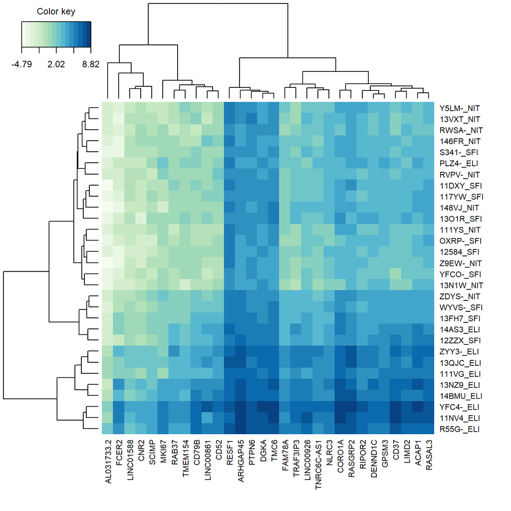

```r
> # SFIvsELI
>
> logCPM <- cpm(dg_list_2, prior.count = 2, log = T)
>
> rownames(logCPM) <- res_ann_SFIvsELI$SYMBOL
> colnames(logCPM) <- as.character(dg_list_2$samples$short_name)
>
> o <- order(res_ann_SFIvsELI$PValue)
>
> logCPM <- logCPM[o[1:30], ]
>
> # coolmap(logCPM, margins=c(7,7), lhei=c(1,6), lwid=c(1,3))
> cim(t(logCPM), color = sort(hmcol, decreasing = T), symkey = FALSE,
+     margins = c(7, 7))
```

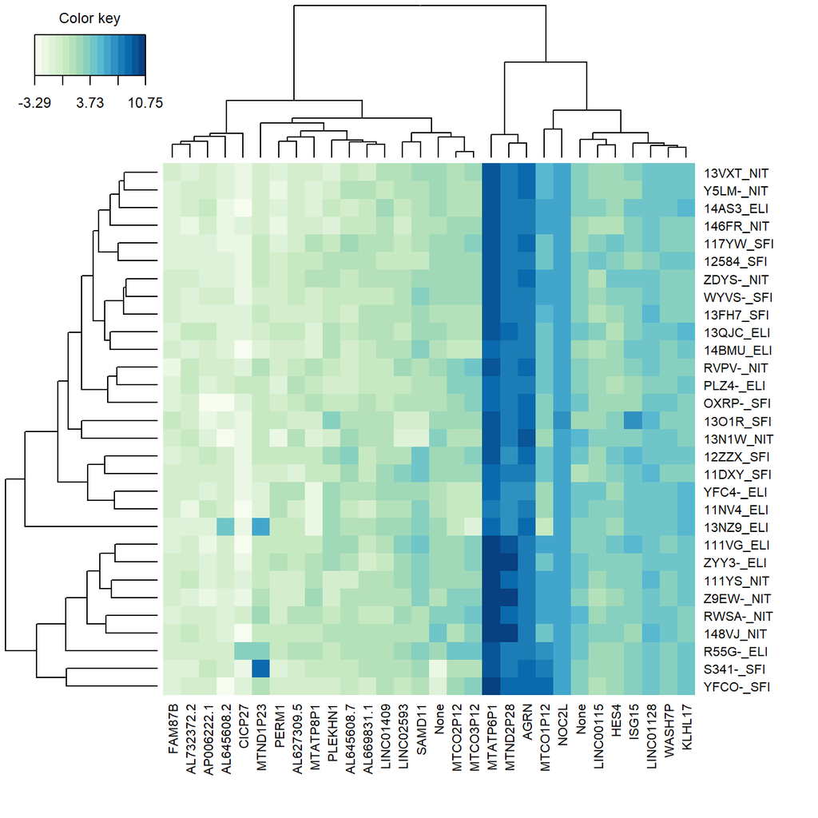

```r
> # NITvsELI
>
> logCPM <- cpm(dg_list_2, prior.count = 2, log = T)
>
> rownames(logCPM) <- res_ann_NITvsELI$SYMBOL
> colnames(logCPM) <- as.character(dg_list_2$samples$short_name)
>
> o <- order(res_ann_NITvsELI_ordered$PValue)
>
> logCPM <- logCPM[o[1:30], ]
>
> # coolmap(logCPM, margins=c(7,7), lhei=c(1,6), lwid=c(1,3))
> cim(t(logCPM), color = sort(hmcol, decreasing = T), symkey = FALSE,
+     margins = c(7, 7))
```

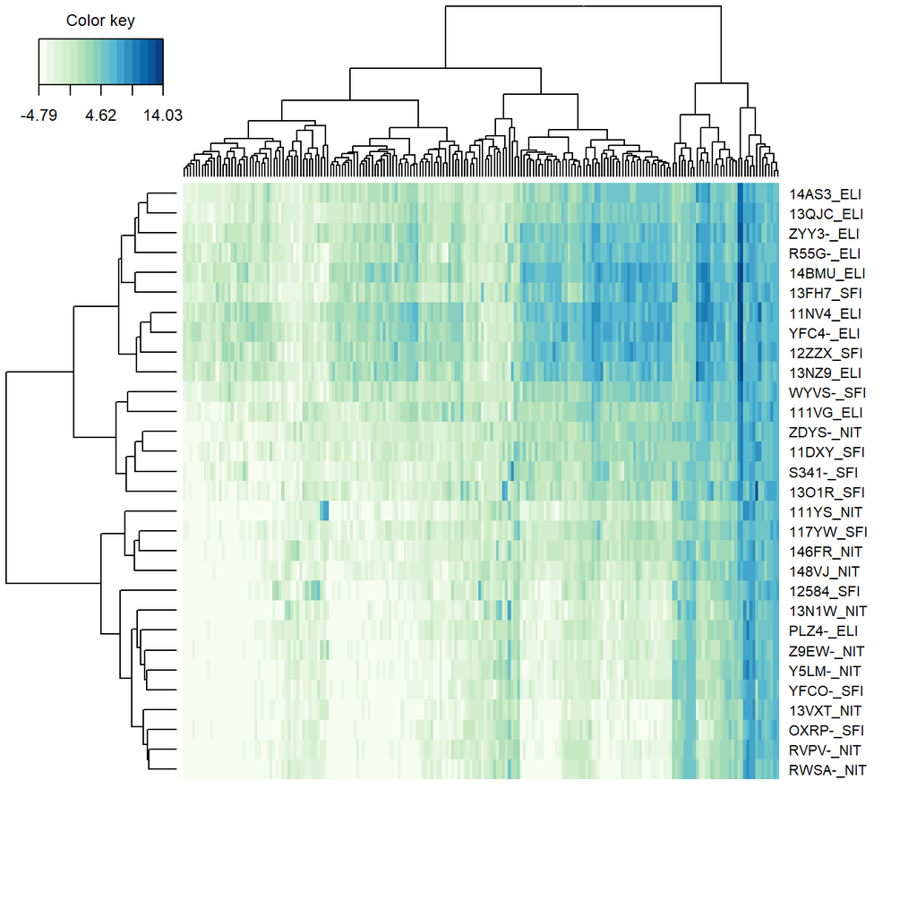

```r
> # ann$SYMBOL eliminado, se ve mejor sin los nombres de los
> # genes
>
> # NITvsSFI
> logCPM <- cpm(dg_list_2, prior.count = 2, log = T)
>
>
> rownames(logCPM) <- c(rep("", 19457))
> colnames(logCPM) <- as.character(dg_list_2$samples$short_name)
>
> o <- order(res_ann_NITvsSFI$PValue)
>
> logCPM <- logCPM[o[1:200], ]
>
> # coolmap(logCPM, margins=c(7,7), lhei=c(1,6), lwid=c(1,3))
> cim(t(logCPM), color = sort(hmcol, decreasing = T), symkey = FALSE,
+     margins = c(7, 7))
```

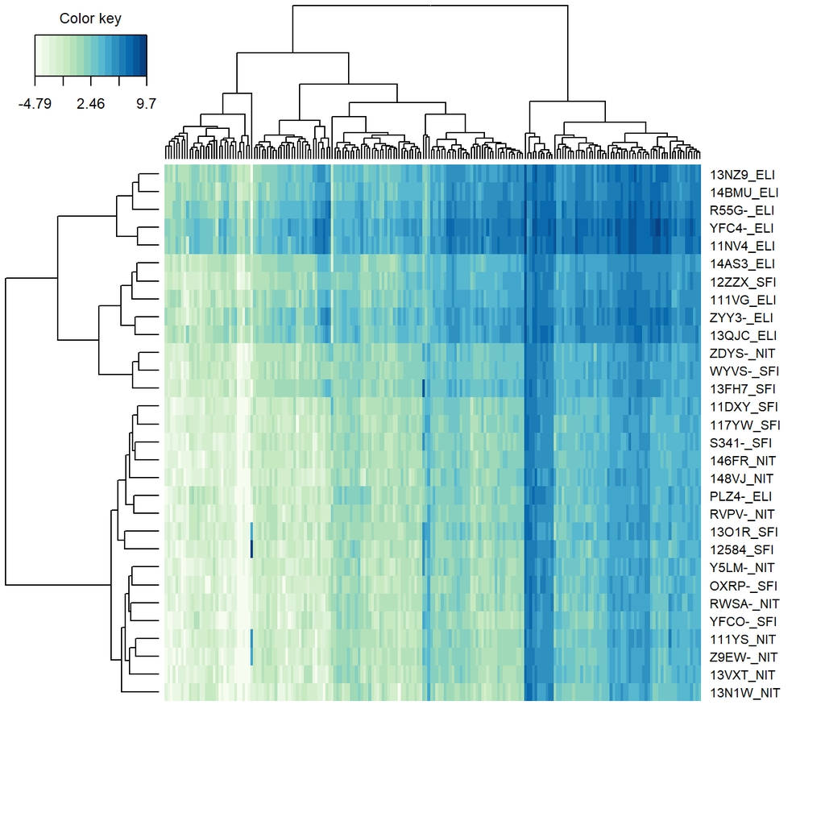

```r
> # SFIvsELI
> logCPM <- cpm(dg_list_2, prior.count = 2, log = T)
>
> rownames(logCPM) <- c(rep("", 19457))
> colnames(logCPM) <- as.character(dg_list_2$samples$short_name)
>
> o <- order(res_ann_SFIvsELI$PValue)
>
> logCPM <- logCPM[o[1:200], ]
>
> # coolmap(logCPM, margins=c(7,7), lhei=c(1,6), lwid=c(1,3))
> cim(t(logCPM), color = sort(hmcol, decreasing = T), symkey = FALSE,
+     margins = c(7, 7))
```

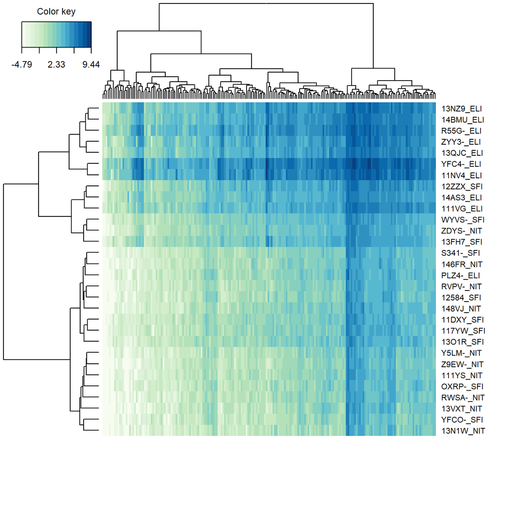

```r
> # NITvsELI
> logCPM <- cpm(dg_list_2, prior.count = 2, log = T)
>
> rownames(logCPM) <- c(rep("", 19457))
> colnames(logCPM) <- as.character(dg_list_2$samples$short_name)
>
> o <- order(res_ann_NITvsELI$PValue)
>
> logCPM <- logCPM[o[1:200], ]
>
> # coolmap(logCPM, margins=c(7,7), lhei=c(1,6), lwid=c(1,3))
> cim(t(logCPM), color = sort(hmcol, decreasing = T), symkey = FALSE,
+     margins = c(7, 7))
```